# Image Captioning

## Encoder Decoder Network

Last tutorial we introduced the encoder-decoder structure for translation. Rather than one model, we have two:

- Encoder that maps the input to some conceptual representation rather than individual words.
- Decoder that maps the representation into output words.

[figure not shown]

## Image Encoder, Text Decoder

Since we have a separate encoder and decoder, we could also have an encoder that encodes images, and a decoder that decodes text, giving us an image captioning model.

[figure not shown]

## Encoder: Convolutional Neural Network

Wheras recurrent neural networks' repeating structure makes it a natural fit for sequential sentence data, convolutional neural networks are a natural fit for images.

[figure not shown]

Convolutions look for visual traits in local patches in images, such as shapes and colors.

[figure not shown]

# Exercise: Image Captioning

Today we'll implement an image captioning model to describe images.

## Requirements

```python
from collections import Counter, defaultdict
from gensim.models import Word2Vec
from IPython import display
from nltk import word_tokenize
from nltk.translate.bleu_score import sentence_bleu
from PIL import Image
from torch import nn
from torch.autograd import Variable
from torchvision import models, transforms

import json
import matplotlib
import numpy as np
import matplotlib.pyplot as plt
import random
import torch
import torch.nn.functional as F
```

Here we will also define a constant to decide whether to use the GPU (with CUDA specifically) or the CPU. **If you don't have a GPU, set this to `False`**. Later when we create tensors, this variable will be used to decide whether we keep them on CPU or move them to GPU.

```python
use_cuda = True
```

## Loading Data

The dataset, MSCOCO, contains 5 English captions per image.

We will be representing each word in a language as a one-hot vector, or giant vector of zeros except for a single one (at the index of the word). Compared to the dozens of characters that might exist in a language, there are many many more words, so the encoding vector is much larger.

There's a bit of pre-processing code below, that loads the data and converts it into one-hot vectors.

```python
# Load annotations file for the training images.
mscoco_train = json.load(open('data/annotations/train_captions.json'))
train_ids = [entry['id'] for entry in mscoco_train['images']][:1000]
train_id_to_file = {entry['id']: 'data/train2014/' + entry['file_name'] for entry in mscoco_train['images']}

# Extract out the captions for the training images
train_id_set = set(train_ids)
train_id_to_captions = defaultdict(list)
for entry in mscoco_train['annotations']:
    if entry['image_id'] in train_id_set:
        train_id_to_captions[entry['image_id']].append(entry['caption'])

# Load annotations file for the validation images.
mscoco_val = json.load(open('data/annotations/val_captions.json'))
val_ids = [entry['id'] for entry in mscoco_val['images']]
val_id_to_file = {entry['id']: 'data/val2014/' + entry['file_name'] for entry in mscoco_val['images']}

# Extract out the captions for the validation images
val_id_set = set(val_ids)
val_id_to_captions = defaultdict(list)
for entry in mscoco_val['annotations']:
    if entry['image_id'] in val_id_set:
        val_id_to_captions[entry['image_id']].append(entry['caption'])

# Load annotations file for the testing images
mscoco_test = json.load(open('data/annotations/test_captions.json'))
test_ids = [entry['id'] for entry in mscoco_test['images']]
test_id_to_file = {entry['id']: 'data/val2014/' + entry['file_name'] for entry in mscoco_test['images']}
```

```python
sentences = [sentence for caption_set in train_id_to_captions.values() for sentence in caption_set]

# Lower-case the sentence, tokenize them and add <SOS> and <EOS> tokens
sentences = [["<SOS>"] + word_tokenize(sentence.lower()) + ["<EOS>"] for sentence in sentences]

# Create the vocabulary. Note that we add an <UNK> token to represent words not in our vocabulary.
vocabularySize = 1000
word_counts = Counter([word for sentence in sentences for word in sentence])
vocabulary = ["<UNK>"] + [e[0] for e in word_counts.most_common(vocabularySize-1)]
word2index = {word:index for index,word in enumerate(vocabulary)}
one_hot_embeddings = np.eye(vocabularySize)

# Define the max sequence length to be the longest sentence in the training data.
maxSequenceLength = max([len(sentence) for sentence in sentences])

def preprocess_numberize(sentence):
    """
    Given a sentence, in the form of a string, this function will preprocess it
    into list of numbers (denoting the index into the vocabulary).
    """
    tokenized = word_tokenize(sentence.lower())

    # Add the <SOS>/<EOS> tokens and numberize (all unknown words are represented as <UNK>).
    tokenized = ["<SOS>"] + tokenized + ["<EOS>"]
    numberized = [word2index.get(word, 0) for word in tokenized]

    return numberized

def preprocess_one_hot(sentence):
    """
    Given a sentence, in the form of a string, this function will preprocess it
    into a numpy array of one-hot vectors.
    """
    numberized = preprocess_numberize(sentence)

    # Represent each word as it's one-hot embedding
    one_hot_embedded = one_hot_embeddings[numberized]

    return one_hot_embedded
```

```python
# Define a global transformer to appropriately scale images and subsequently convert them to a Tensor.
img_size = 224
loader = transforms.Compose([
  transforms.Resize(img_size),
  transforms.CenterCrop(img_size),
  transforms.ToTensor(),
])
def load_image(filename, volatile=False):
    """
    Simple function to load and preprocess the image.

    1. Open the image.
    2. Scale/crop it and convert it to a float tensor.
    3. Convert it to a variable (all inputs to PyTorch models must be variables).
    4. Add another dimension to the start of the Tensor (b/c VGG expects a batch).
    5. Move the variable onto the GPU.
    """
    image = Image.open(filename).convert('RGB')
    image_tensor = loader(image).float()
    image_var = Variable(image_tensor, volatile=volatile).unsqueeze(0)
    return image_var.cuda()
```

### Exploring Data

We can explore the data a bit, to get a sense of what we're working with.

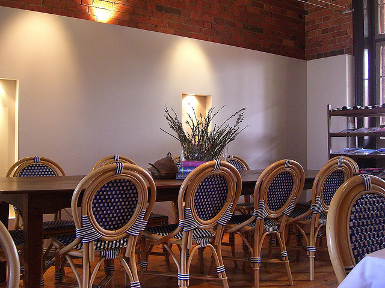

```
A restaurant has modern wooden tables and chairs.
A long restaurant table with rattan rounded back chairs.
a long table with a plant on top of it surrounded with wooden chairs
A long table with a flower arrangement in the middle for meetings
A table is adorned with wooden chairs with blue accents.
```

```python
display.display(Image.open(train_id_to_file[train_ids[0]]))

for caption in train_id_to_captions[train_ids[0]]:
    print(caption)
```

## Image Encoder

We load in a pre-trained VGG-16 model and remove the final layer. This is similar to what we did when doing the hotdog/not-hotdog tutorial/competition.

```python
vgg_model = models.vgg16(pretrained=True).cuda()
vgg_model.eval()

# Remove the final layer of the classifier, and indicate to PyTorch that the model is being used for inference
# rather than training (most importantly, this disables dropout).
modified_classifier = nn.Sequential(*list(vgg_model.classifier.children())[:-1])
modified_classifier.eval()

# Reassign the modified classifier back to the VGG model
vgg_model.classifier = modified_classifier

# Print out the model to see what it looks like now
vgg_model
```

```
VGG(
  (features): Sequential(
    (0): Conv2d(3, 64, kernel_size=(3, 3), stride=(1, 1), padding=(1, 1))
    (1): ReLU(inplace)
    (2): Conv2d(64, 64, kernel_size=(3, 3), stride=(1, 1), padding=(1, 1))
    (3): ReLU(inplace)
    (4): MaxPool2d(kernel_size=(2, 2), stride=(2, 2), dilation=(1, 1), ceil_mode=False)
    (5): Conv2d(64, 128, kernel_size=(3, 3), stride=(1, 1), padding=(1, 1))
    (6): ReLU(inplace)
    (7): Conv2d(128, 128, kernel_size=(3, 3), stride=(1, 1), padding=(1, 1))
    (8): ReLU(inplace)
    (9): MaxPool2d(kernel_size=(2, 2), stride=(2, 2), dilation=(1, 1), ceil_mode=False)
    (10): Conv2d(128, 256, kernel_size=(3, 3), stride=(1, 1), padding=(1, 1))
    (11): ReLU(inplace)
    (12): Conv2d(256, 256, kernel_size=(3, 3), stride=(1, 1), padding=(1, 1))
    (13): ReLU(inplace)
    (14): Conv2d(256, 256, kernel_size=(3, 3), stride=(1, 1), padding=(1, 1))
    (15): ReLU(inplace)
    (16): MaxPool2d(kernel_size=(2, 2), stride=(2, 2), dilation=(1, 1), ceil_mode=False)
    (17): Conv2d(256, 512, kernel_size=(3, 3), stride=(1, 1), padding=(1, 1))
    (18): ReLU(inplace)
    (19): Conv2d(512, 512, kernel_size=(3, 3), stride=(1, 1), padding=(1, 1))
    (20): ReLU(inplace)
    (21): Conv2d(512, 512, kernel_size=(3, 3), stride=(1, 1), padding=(1, 1))
    (22): ReLU(inplace)
    (23): MaxPool2d(kernel_size=(2, 2), stride=(2, 2), dilation=(1, 1), ceil_mode=False)
    (24): Conv2d(512, 512, kernel_size=(3, 3), stride=(1, 1), padding=(1, 1))
    (25): ReLU(inplace)
    (26): Conv2d(512, 512, kernel_size=(3, 3), stride=(1, 1), padding=(1, 1))
    (27): ReLU(inplace)
    (28): Conv2d(512, 512, kernel_size=(3, 3), stride=(1, 1), padding=(1, 1))
    (29): ReLU(inplace)
    (30): MaxPool2d(kernel_size=(2, 2), stride=(2, 2), dilation=(1, 1), ceil_mode=False)
  )
  (classifier): Sequential(
    (0): Linear(in_features=25088, out_features=4096, bias=True)
    (1): ReLU(inplace)
    (2): Dropout(p=0.5)
    (3): Linear(in_features=4096, out_features=4096, bias=True)
    (4): ReLU(inplace)
    (5): Dropout(p=0.5)
  )
)
```

## Process Data

We now convert each image, into a vector representation, that serves as a semantic descriptor of the image. We do this by passing it through our modified VGG-16 model.

```python
training_vectors = []
for i,image_id in enumerate(train_ids):
    # Load/preprocess the image.
    img = load_image(train_id_to_file[image_id])

    # Run through the convolutional layers and resize the output.
    output = vgg_model(img)

    training_vectors.append(np.array(list(output.data.squeeze())))

# For simplicity, we convert this to a numpy array and save the result to a file.
training_vectors = np.stack(training_vectors, axis=0)
np.save(open('outputs/training_vectors', 'wb+'), training_vectors)
```

```python
# Next we vectorize all of the validation images and write the results to a file.
validation_vectors = []
for image_id in val_ids:
    # Load/preprocess the image.
    img = load_image(val_id_to_file[image_id])

    # Run through the convolutional layers and resize the output.
    features_output = vgg_model.features(img)
    classifier_input = features_output.view(1, -1)

    # Run through all but final classifier layers.
    output = modified_classifier(classifier_input)
    validation_vectors.append(list(output.data.squeeze()))

# For simplicity, we convert this to a numpy array and save the result to a file.
validation_vectors = np.array(validation_vectors)
np.save(open('outputs/validation_vectors', 'wb+'), validation_vectors)
```

```python
# Load in the vectors and print their sizes
training_vectors = np.load(open('outputs/training_vectors', 'rb'))
validation_vectors = np.load(open('outputs/validation_vectors', 'rb'))

print(training_vectors.shape)
print(validation_vectors.shape)

train_id_to_vector = {}
for i, train_id in enumerate(train_ids[:1000]):
    train_id_to_vector[train_id] = training_vectors[i]
```

```
(1000, 4096)
(100, 4096)
```

# Image Captioning Model

Since we have a separate encoder and decoder, we could also have an encoder that encodes images, and a decoder that decodes text, giving us an image captioning model.

[figure not shown]

```python
class ImageEncoder(nn.Module):
    def __init__(self, input_size, hidden_size):
        super(ImageEncoder, self).__init__()
        self.out = nn.Linear(input_size, hidden_size)

    def forward(self, inputs):
        return self.out(inputs)

class DecoderLSTM(nn.Module):
    def __init__(self, input_size, hidden_size, output_size):
        super(DecoderLSTM, self).__init__()
        self.hidden_size = hidden_size

        self.lstm = nn.LSTM(input_size, hidden_size)
        self.out = nn.Linear(hidden_size, output_size)

    def forward(self, input, hidden):
        output = F.relu(input)
        output, hidden = self.lstm(output, hidden)
        output = self.out(output)
        output = F.log_softmax(output.squeeze())
        return output.unsqueeze(0), hidden

encoder = ImageEncoder(input_size=4096, hidden_size=300).cuda()
decoder = DecoderLSTM(input_size=len(vocabulary), hidden_size=300, output_size=len(vocabulary)).cuda()
```

```python
encoder
```

```
ImageEncoder(
  (out): Linear(in_features=4096, out_features=300, bias=True)
)
```

```python
decoder
```

```
DecoderLSTM(
  (lstm): LSTM(1000, 300)
  (out): Linear(in_features=300, out_features=1000, bias=True)
)
```

# Training the Models

## Defining the Loss Function

The next two functions are part of some other deep learning frameworks, but PyTorch has not yet implemented them. We can find some commonly-used open source worked arounds after searching around a bit: https://gist.github.com/jihunchoi/f1434a77df9db1bb337417854b398df1.

```python
# The next two functions are part of some other deep learning frameworks, but PyTorch
# has not yet implemented them. We can find some commonly-used open source worked arounds
# after searching around a bit: https://gist.github.com/jihunchoi/f1434a77df9db1bb337417854b398df1.
def _sequence_mask(sequence_length, max_len=None):
    if max_len is None:
        max_len = sequence_length.data.max()
    batch_size = sequence_length.size(0)
    seq_range = torch.arange(0, max_len).long()
    seq_range_expand = seq_range.unsqueeze(0).expand(batch_size, max_len)
    seq_range_expand = Variable(seq_range_expand)
    if sequence_length.is_cuda:
        seq_range_expand = seq_range_expand.cuda()
    seq_length_expand = (sequence_length.unsqueeze(1)
                         .expand_as(seq_range_expand))
    return seq_range_expand < seq_length_expand


def compute_loss(logits, target, length):
    """
    Args:
        logits: A Variable containing a FloatTensor of size
            (batch, max_len, num_classes) which contains the
            unnormalized probability for each class.
        target: A Variable containing a LongTensor of size
            (batch, max_len) which contains the index of the true
            class for each corresponding step.
        length: A Variable containing a LongTensor of size (batch,)
            which contains the length of each data in a batch.

    Returns:
        loss: An average loss value masked by the length.
    """
    # logits_flat: (batch * max_len, num_classes)
    logits_flat = logits.view(-1, logits.size(-1))
    # log_probs_flat: (batch * max_len, num_classes)
    log_probs_flat = logits_flat
    # target_flat: (batch * max_len, 1)
    target_flat = target.view(-1, 1)
    # losses_flat: (batch * max_len, 1)
    losses_flat = -torch.gather(log_probs_flat, dim=1, index=target_flat)
    # losses: (batch, max_len)
    losses = losses_flat.view(*target.size())
    # mask: (batch, max_len)
    mask = _sequence_mask(sequence_length=length, max_len=target.size(1))
    losses = losses * mask.float()
    loss = losses.sum() / length.float().sum()
    return loss
```

## Training Function

The function below trains the model. There's some interesting ideas in the function below, such as:

- Teacher forcing
- Masked loss
- Gradient Clipping

```python
def train(input_variables,
          embed_caption,
          target_caption,
          input_lens,
          encoder,
          decoder,
          encoder_optimizer,
          decoder_optimizer,
          criterion,
          embeddings=one_hot_embeddings):
    encoder_optimizer.zero_grad()
    decoder_optimizer.zero_grad()

    # Pass the image through the encoder
    encoder_output = encoder(input_variables).unsqueeze(0)

    # Construct the decoder input (initially <SOS> for every batch)
    decoder_input = Variable(torch.FloatTensor([[embeddings[word2index["<SOS>"]]
                                                for i in range(embed_caption.size(1))]]))
    decoder_input = decoder_input.cuda() if use_cuda else decoder_input

    # Set the initial hidden state of the decoder to be the output of the encoder
    decoder_hidden = (encoder_output, encoder_output)

    # Prepare the results tensor
    all_decoder_outputs = Variable(torch.zeros(*embed_caption.size()))
    if use_cuda:
        all_decoder_outputs = all_decoder_outputs.cuda()

    all_decoder_outputs[0] = decoder_input

    # Iterate over the indices after the first.
    for t in range(1,embed_caption.size(0)):
        decoder_output, decoder_hidden = decoder(decoder_input, decoder_hidden)

        if random.random() <= 0.8:
            decoder_input = embed_caption[t].unsqueeze(0)
        else:
            topv, topi = decoder_output.data.topk(1)

            #Prepare the inputs
            decoder_input = torch.stack([Variable(torch.FloatTensor(embeddings[ni])).cuda()
                                         for ni in topi.squeeze()]).unsqueeze(0)

        # Save the decoder output
        all_decoder_outputs[t] = decoder_output

    loss = compute_loss(all_decoder_outputs.transpose(0,1).contiguous(),
                        target_caption.transpose(0,1).contiguous(),
                        Variable(torch.LongTensor(input_lens)).cuda())

    loss.backward()

    torch.nn.utils.clip_grad_norm(encoder.parameters(), 10.0)
    torch.nn.utils.clip_grad_norm(decoder.parameters(), 10.0)

    encoder_optimizer.step()
    decoder_optimizer.step()

    return loss.data[0]
```

## Training the Model

Let's take a look at the first few images in the validation set, to get a sense of the captions that should be generated by our model.

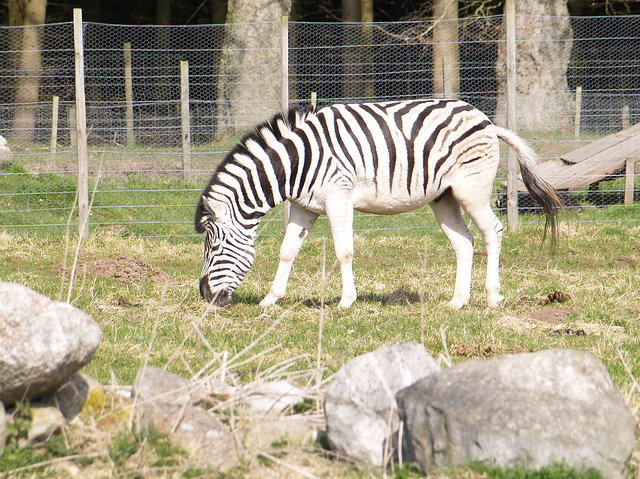

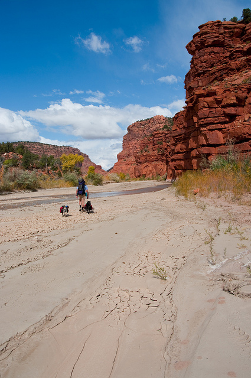

[figure not shown]

```python
display.display(Image.open(val_id_to_file[val_ids[0]]))
display.display(Image.open(val_id_to_file[val_ids[1]]))
display.display(Image.open(val_id_to_file[val_ids[2]]))
```

```python
def pad_seq(arr, length, pad_token):
    """
    Pad an array to a length with a token.
    """
    if len(arr) == length:
        return np.array(arr)

    return np.concatenate((arr, [pad_token]*(length - len(arr))))

encoder_optimizer = torch.optim.Adam(decoder.parameters(), lr=0.01)
decoder_optimizer = torch.optim.Adam(decoder.parameters(), lr=0.01)
criterion = nn.CrossEntropyLoss()

# Formulate the training data
train_data = [(train_id,caption) for train_id,captions in train_id_to_captions.items()
              for caption in captions if len(caption) > 0]
random.shuffle(train_data)

num_epochs = 10
batch_size = 100
for _ in range(num_epochs):
    for i in range(len(train_data)//batch_size):
        # Get the data in the batch
        batch = train_data[i*batch_size:(i+1)*batch_size]

        # Get all of the image vectors
        input_variable = np.stack([train_id_to_vector[train_id] for train_id,_ in batch])
        input_variable = Variable(torch.FloatTensor(input_variable)).cuda()

        # Get the sentences
        sentences = [sentence for _,sentence in batch]

        # Get the sentence lengths
        sentence_lens = [len(preprocess_numberize(sentence)) for sentence in sentences]

        # Determine length to pad everything to
        max_len = max(sentence_lens)

        # Preprocess all of the sentences in each batch
        one_hot_embedded_list = [preprocess_one_hot(sentence) for sentence in sentences]
        one_hot_embedded_list_padded = [pad_seq(embed, max_len, np.zeros(len(vocabulary)))
                                        for embed in one_hot_embedded_list]

        numberized_list = [preprocess_numberize(sentence) for sentence in sentences]
        numberized_list_padded = [pad_seq(numb, max_len, 0).astype(torch.LongTensor) for numb in numberized_list]

        # Convert to variables
        embed_caption = Variable(torch.FloatTensor(one_hot_embedded_list_padded)).cuda()
        target_caption = Variable(torch.LongTensor(numberized_list_padded)).cuda()

        # Transpose from batch_size x max_seq_len x vocab_size to max_seq_len x batch_size x vocab_size
        embed_caption = embed_caption.transpose(0, 1)
        target_caption = target_caption.transpose(0, 1)

        loss = train(input_variable,
                     embed_caption,
                     target_caption,
                     sentence_lens,
                     encoder,
                     decoder,
                     encoder_optimizer,
                     decoder_optimizer,
                     criterion)

        if i % 10 == 0:
            print(i,loss)

        if i % 100 == 0:
            print(caption_image(validation_vectors[0]))
            print(caption_image(validation_vectors[1]))
            print(caption_image(validation_vectors[2]))
```

```
0 1.0996862649917603
two zebras in a grassy area , mountains . <EOS>
a <UNK> <UNK> a beach with two people in water <EOS>
the three zebra walking through a green field . <EOS>
10 0.9388931393623352
20 0.8056912422180176
30 0.8283523917198181
40 1.1488995552062988
0 1.0501055717468262
two zebras are grazing together in an open field . <EOS>
a man riding a <UNK> <UNK> on a beach <EOS>
a zebra standing up a lush green field under a sunny day . <EOS>
10 0.9093959331512451
20 0.6028589606285095
30 0.9106595516204834
40 1.1929987668991089
0 0.8078488707542419
two zebras are standing behind a fence . <EOS>
a man riding a <UNK> on a beach <EOS>
a zebra standing on a lush green and dry grass field . <EOS>
10 0.7439531087875366
20 0.5075826644897461
30 0.51601642370224
40 0.6893169283866882
0 0.6633409857749939
two zebras are standing behind a field . <EOS>
a man riding on the beach , with a bunch of kites <EOS>
a zebra standing on a dry grass field . <EOS>
10 0.7824536561965942
20 0.6004353761672974
30 1.0627655982971191
40 0.8339794874191284
0 0.7177368402481079
a zebra that is standing in the grass . <EOS>
a man riding a <UNK> of an old photo camera <EOS>
a zebra standing on a dry grass field . <EOS>
10 0.7741029858589172
20 0.6749404668807983
30 0.5230371952056885
40 0.4984515607357025
```

[output cut: 25 more lines]

```
two zebras are standing under a grassy field . <EOS>
a very bench bench is near some horses <EOS>
a <UNK> of zebra standing next to a <UNK> of <UNK> . <EOS>
10 0.5476540923118591
20 0.4898291230201721
30 0.6118215918540955
40 0.3913015127182007
0 0.5958134531974792
a zebra that is standing in the grass . <EOS>
a very small boat <UNK> in the water with the water with the <UNK> behind the . <EOS>
the three zebra <UNK> on the <UNK> next to trees . <EOS>
10 1.15800142288208
20 1.347028374671936
30 0.5429417490959167
40 0.6297010779380798
```

# Captioning!

Finally, we write a very simple method to run captioning for a given image vector.

```python
def caption_image(image_vector, embeddings=one_hot_embeddings, max_length=20):
    """
    Given an image vector, caption the image.
    """
    # Pass the image through the encoder
    input_variable = Variable(torch.FloatTensor([image_vector])).cuda()
    encoder_output = encoder(input_variable).unsqueeze(0)

    # Construct the decoder input (initially <SOS> for every batch)
    decoder_input = Variable(torch.FloatTensor([[embeddings[word2index["<SOS>"]]]])).cuda()

    # Set the initial hidden state of the decoder to be the output of the encoder
    decoder_hidden = (encoder_output, encoder_output)

    # Iterate over the indices after the first.
    decoder_outputs = []
    for t in range(1,max_length):
        decoder_output, decoder_hidden = decoder(decoder_input, decoder_hidden)

        # Get the top result
        topv, topi = decoder_output.data.topk(1)
        ni = topi[0][0]
        decoder_outputs.append(ni)

        if vocabulary[ni] == "<EOS>":
            break

        #Prepare the inputs
        decoder_input = Variable(torch.FloatTensor([[embeddings[ni]]])).cuda()
        decoder_input = decoder_input.cuda() if use_cuda else decoder_input

    return ' '.join(vocabulary[i] for i in decoder_outputs)
```

[figure not shown]

```
'the three zebra walking through an open field . <EOS>'
```

```python
display.display(display.Image(val_id_to_file[val_ids[2]]))

caption_image(validation_vectors[2])
```